# 1MP3 Exam Review 2016

Dexter Barrows

Tuesday April 5, 2016

[Python documentation reference](https://docs.python.org/3/tutorial).

# PRE-MIDTERM

This section is a duplicate of the Midterm Review, repeated here for easy access.

## Strings

Arrays of characters, can be used to hold single characters, words, sentences, user input/output, etc. Strings are declared using single or double quotes.

```python
c   = "a"
wd  = "moxie"
sen = "Your midterm is on Friday!"
print(c)
print(wd)
print(sen)
```

```
## a
## moxie
## Your midterm is on Friday!
```

They can be easily concatenated or repeated.

```python
print("hi" + "there")
print(3*"blah")
```

```
## hithere
## blahblahblah
```

#### Building Strings

You can ‘build’ strings by creating an empty string and adding to it

```python
s = ""
s += "What's"
s += " "
s += "up?"
print(s)
```

```
## What's up?
```

## Lists

Lists are used to store arrays of any type. They can all be the same type (for example `int`), or differing types. They can also be added together like strings.

```python
numlist  = [1, 2, 3, 4, 5, 525600]
wordlist = ['this', 'is', 'a', 'list', 'of', 'words']
print(numlist)
print(wordlist)
print(numlist + wordlist)
```

```
## [1, 2, 3, 4, 5, 525600]
## ['this', 'is', 'a', 'list', 'of', 'words']
## [1, 2, 3, 4, 5, 525600, 'this', 'is', 'a', 'list', 'of', 'words']
```

#### Nested Lists

Lists can be nested too (lists in lists).

```python
nestlist = [[1,2,3],[4,5,6],[]]
print(nestlist)
```

```
## [[1, 2, 3], [4, 5, 6], []]
```

Useful methods for working with lists include `append()` for adding a **single** element to the end of a list, *no matter what type it is*.

```python
numlist = [1, 2, 3]
print(numlist)
numlist.append(4)
print(numlist)
numlist.append([5])
print(numlist)
```

```
## [1, 2, 3]
## [1, 2, 3, 4]
## [1, 2, 3, 4, [5]]
```

An alternative method, `extend()`, can be used to concatenate lists similar to using the plus (`+`) operator. Note that `extend()` expects its argument to be a list.

```python
numlist = [1, 2, 3]
print(numlist)
numlist.extend([4])
print(numlist)
numlist.extend([5, 6, 7])
print(numlist)
```

```
## [1, 2, 3]
## [1, 2, 3, 4]
## [1, 2, 3, 4, 5, 6, 7]
```

#### Note on Mutability

If you assign a list variable to another variable, both variables will point **at the same list**.

```python
L1 = [1, 2, 3, 4, 5]
L2 = L1
L2.append(55)
print(L1)
print(L2)
```

```
## [1, 2, 3, 4, 5, 55]
## [1, 2, 3, 4, 5, 55]
```

#### Useful methods for Lists

Some other helpful methods for working with lists (from class notes):

- `x.remove(value)`: removes *first* value
- `x.reverse()` (or `x[::-1]`)
- `x.index(value)`: first occurrence of `value`
- `len(x)`: length

## Tuples

Similar to lists, but are **immutable** (more on that later).

```python
tup = (1, 2, 3, (4, 5))
print(tup)
```

```
## (1, 2, 3, (4, 5))
```

## Indexing and Slicing

Strings, lists, and tuples all support indexing and slicing. This means we can access individual elements or ranges of elements in any of these types. Recall that element **indices start at 0**.

```python
nums = [1,2,3,4,5]
s = "Pythons are snakes"
print(nums[0])      # indexing
print(nums[1:4])    # slicing
print(s[-1])        # indexing from end
print(s[-3:])       # slicing to end
```

```
## 1
## [2, 3, 4]
## s
## kes
```

With nested lists/tuples, double indexing is used.

```python
tup = ((1,2,3),(4,5))
print(tup[0])
print(tup[0][1])
print(tup[-1][-1])
```

```
## (1, 2, 3)
## 2
## 5
```

With lists you can assign *to* elements using indexing/slicing, this **does not** work with strings/tuples as they are **immutable**.

```python
numlist = [[1, 2, 3], [], [4, 5]]
print(numlist)
numlist[0][2] = 42
print(numlist)
```

```
## [[1, 2, 3], [], [4, 5]]
## [[1, 2, 42], [], [4, 5]]
```

## If statements

If statements can be used to conditionally execute code. We usually check conditions using logical operators such as

- `==` equal to
- `!=` not equal to
- `<` less than
- `<=` less than or equal to
- `>` greater than
- `>=` greater than or equal to

For example:

```python
x = 5
if x < 17:
    print("x is smaller")
```

```
## x is smaller
```

Alternative conditions can be checked at the same time using `elif` statements, and a default action can be set using `else`.

```python
x = 42
if x < 17:
    print("x is smaller")
elif x > 17:
    print("x is bigger")
else:
    print("x is the same")
```

```
## x is bigger
```

## Loops

We can repeatedly carry out sequences of instructions using `for` or `while` loops. Traditionally, `for` loops are used when we know how long the loop needs to run for, and `while` loops are used when we do not ro would rather have the computer figure it out.

```python
for i in range(10):
    print(i)
```

```
## 0
## 1
## 2
## 3
## 4
## 5
## 6
## 7
## 8
## 9
```

```python
i = 0
while i**2 < 87:
    print(i)
    i += 2
```

```
## 0
## 2
## 4
## 6
## 8
```

## Functions

We can define functions to store sections of code we want to run repeatedly. The input/output is specified using arguments and return statements

```python
def add1(x):
    x += 1
    return(x)

x = 3
print(add1(x))
print(x)
```

```
## 4
## 3
```

Note that `x` is not modified in the above example because it is **immutable**. Immutable types are numbers (`int`/`float`), strings, and tuples. Imporatant: **lists are mutable**.

```python
def append4(list):
    list.append(4)
    return(list)

numlist = [1,2,3]
print(append4(numlist))
print(numlist)
```

```
## [1, 2, 3, 4]
## [1, 2, 3, 4]
```

# POST-MIDTERM

Everything that follows covers material since the midterm.

## Dictionaries

Stores unordered key-value pair data.

```python
dict = {"a":1, "b":2, "c":3}
print(dict)
```

```
## {'a': 1, 'b': 2, 'c': 3}
```

You can extract iterables over the keys or values. Recall that they are **unordered**.

```python
dict = {"a":1, "b":2, "c":3}
print(dict.keys())
print(dict.values())
```

```
## dict_keys(['b', 'a', 'c'])
## dict_values([2, 1, 3])
```

Value insertion / deletion is done using the keys.

```python
dict = {"a":1, "b":2, "c":3}
print(dict)

x = dict["b"]   ## accessing
print(x)

dict["d"] = 42  ## insertion
print(dict)

del dict["a"]   ## deletion
dict["b"] = 17  ## modification
print(dict)
```

```
## {'c': 3, 'a': 1, 'b': 2}
## 2
## {'c': 3, 'd': 42, 'a': 1, 'b': 2}
## {'c': 3, 'd': 42, 'b': 17}
```

## Numpy

Gives access to convenient data structure and function for working with arrays and matrices.

Performs element-wise operation by default.

```python
import numpy as np

a = np.arange(5)
b = np.arange(5,10)

print("a:  ", a)
print("b:  ", b)
print("a+b:", a+b )     # element-wise addition
print("a*b:", a*b )     # element-wise multiplication
print("2^a:", 2**a)     # scalar expansion - powers
```

```
## a:   [0 1 2 3 4]
## b:   [5 6 7 8 9]
## a+b: [ 5  7  9 11 13]
## a*b: [ 0  6 14 24 36]
## 2^a: [ 1  2  4  8 16]
```

Arrays can be reshaped as long as the number of elements does not change.

```python
import numpy as np

a = np.arange(9).reshape(3,3)
print(a)
```

```
## [[0 1 2]
##  [3 4 5]
##  [6 7 8]]
```

Slicing works Numpy arrays works using a compact `[i,j,...]` notation, with the `:` used as a place-holder to indicate we want to access all elements in that dimension.

```python
import numpy as np

a = np.arange(9).reshape(3,3)

print(a, end = "\n\n")          ## print entire matrix
print(a[1,2], end = "\n\n")     ## print element in second row, third column
print(a[1,:], end = "\n\n")     ## print second row
print(a[:,-1], end = "\n\n")    ## print last column
```

```
## [[0 1 2]
##  [3 4 5]
##  [6 7 8]]
##
## 5
##
## [3 4 5]
##
## [2 5 8]
```

We can perform matrix multiplication using the `dot` function.

```python
import numpy as np

a = np.random.rand(9).reshape(3,3)      ## matrix with random elements
b = np.linalg.inv(a)                    ## take the inverse
c = np.dot(a,b)                         ## matrix multiplication

print(c)
```

```
## [[  1.00000000e+00   2.22044605e-16   6.93889390e-18]
##  [  2.22044605e-16   1.00000000e+00   1.73472348e-18]
##  [ -4.44089210e-16   2.22044605e-16   1.00000000e+00]]
```

## Plotting

Plotting in Python can be done with `matplotlib`.

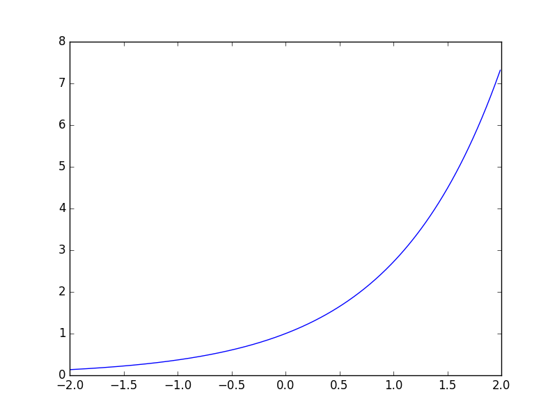

```python
import matplotlib.pyplot as plt
import numpy as np

a = np.arange(-2, 2, 0.01)

plt.plot(a, np.exp(a))              ## plot the exponential function
plt.savefig("exrevpix/plot1.png")   ## save figure
```

Rows of a matrix can be plotted automatically.

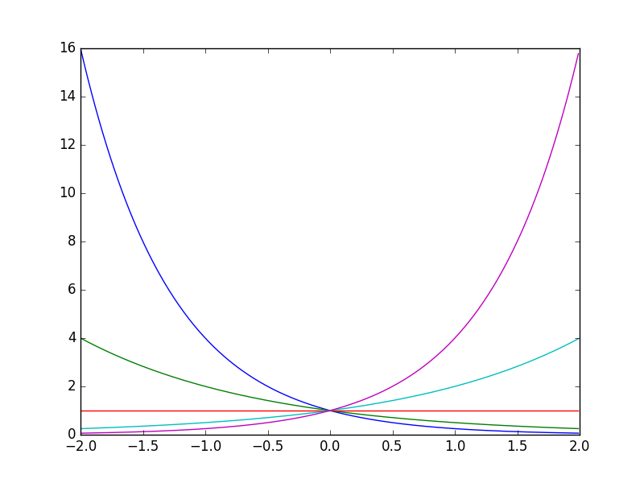

```python
import matplotlib.pyplot as plt
import numpy as np

## plot exponential family with different bases
x = np.arange(-2, 2, 0.01)
b = np.array([1/4, 1/2, 1, 2, 4]).repeat(x.shape[0]).reshape(5, x.shape[0])

y = np.transpose(b**x)

plt.plot(x, y)
plt.savefig("exrevpix/plot2.png")   ## save figure
```

We can use subplots to plot within the same figure. Note that the subplot index (third argument) must be changed in order to change which subplot we are plotting to.

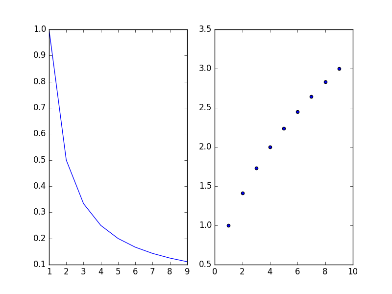

```python
import matplotlib.pyplot as plt
import numpy as np

x = np.arange(1, 10, 1)

plt.subplot(1, 2, 1)
plt.plot(x, 1/x)

plt.subplot(1, 2, 2)
plt.scatter(x, np.sqrt(x))

plt.savefig("exrevpix/plot3.png")
```

## File I/O

Reading from files is done by opening the file and using one of the read functions (`read`, `next`, `readline`, `readlines`).

For example, a file `dune.txt` containing

[output not shown]

can be read and split into a list of words using:

```python
filename = "dune.txt"
f = open(filename)

wordlist = f.read().split()
print(wordlist)
```

```
## ['In', 'the', 'week', 'before', 'their', 'departure', 'to', 'Arrakis,', 'when', 'all', 'the', 'final', 'scurrying', 'about', 'had', 'reached', 'a', 'nearly', 'unbearable', 'frenzy,', 'an', 'old', 'crone', 'came', 'to', 'visit', 'the', 'mother', 'of', 'the', 'boy,', 'Paul']
```

Similarly we could read a list of numbers and insert them into a Numpy array. Given the file `nums.txt` containing:

```
0 1 2 3 4 5 6 7 8 9
```

we can process it using:

```python
import numpy as np

filename = "nums.txt"
f = open(filename)

numlist = f.read().split()
a = np.array(numlist, dtype = int)
print(a)
```

```
## [0 1 2 3 4 5 6 7 8 9]
```

## Pandas

Pandas provides a simple interface for dealing with data frames (organized relational data).

```python
import pandas as pd

pokefile = "pokemon.csv"                                        ## CSV file to read from
pokedata = pd.read_csv(pokefile)                                ## read data from file
pokedata.drop(['order', 'is_default'], axis=1, inplace=True)    ## discard columns we are uninterested in

print( pokedata.head() )                                        ## print first 5 rows
```

```
##    id  identifier  species_id  height  weight  base_experience
## 0   1   bulbasaur           1       7      69               64
## 1   2     ivysaur           2      10     130              142
## 2   3    venusaur           3      20    1000              236
## 3   4  charmander           4       6      85               62
## 4   5  charmeleon           5      11     190              142
```

Note the first column is missing a name – this is the index column. We can change the indices to something easier to read, like the pokémon identifier (name).

```python
import pandas as pd

pokefile = 'pokemon.csv'
pokedata = pd.read_csv(pokefile)
pokedata.drop(['order', 'is_default'], axis=1, inplace=True)

pokedata_orig = pokedata[0:150]                         ## get original 150 pokemon
pokedata_named = pokedata_orig.set_index('identifier')  ## make identifier column the index

print( pokedata_named.head() )

print( pokedata_named.loc['bulbasaur', 'height'] )      ## access by row/column names
print( pokedata_named.iloc[0,2] )                       ## access by row/column index
```

```
##             id  species_id  height  weight  base_experience
## identifier
## bulbasaur    1           1       7      69               64
## ivysaur      2           2      10     130              142
## venusaur     3           3      20    1000              236
## charmander   4           4       6      85               62
## charmeleon   5           5      11     190              142
## 7
## 7
```

We can also access columns directly using the `.` operator, as use it to filter data.

```python
import pandas as pd
import matplotlib.pyplot as plt

pokefile = 'pokemon.csv'
pokedata = pd.read_csv(pokefile)
pokedata.drop(['order', 'is_default'], axis=1, inplace=True)

pokedata_orig = pokedata[0:150]                         ## get original 150 pokemon
pokedata_named = pokedata_orig.set_index('identifier')  ## make identifier column the index

print( "min weight", min(pokedata_named.weight) )       ## get lightest pokemon
print( "max weight", max(pokedata_named.weight) )       ## get heaviest pokemon

lightlim = pokedata_named.quantile(0.05)                                ## get lightest 5% limit
pokelight = pokedata_named[pokedata_named.weight < lightlim['weight']]  ## get data within limit
print(pokelight)

heavylim = pokedata_named.quantile(0.95)                                ## get heaviest 5% limit
pokeheavy = pokedata_named[ pokedata_named.weight > heavylim['weight']] ## get data within limit
print(pokeheavy)

plt.figure()
plt.hist(pokedata_named.weight, bins = 20)
plt.savefig("exrevpix/pokeweight.png")

pokeweight_middle = pokedata_named[(pokedata_named.weight > lightlim['weight']) & (pokedata_named.weight < heavylim['weight'])]
plt.figure()
plt.hist(pokeweight_middle.weight, bins = 20)
plt.savefig("exrevpix/pokeweight2.png")
```

```
## min weight 1
## max weight 4600
##              id  species_id  height  weight  base_experience
## identifier
## caterpie     10          10       3      29               39
## pidgey       16          16       3      18               50
## spearow      21          21       3      20               52
## diglett      50          50       2       8               53
## gastly       92          92      13       1               62
## haunter      93          93      16       1              142
## exeggcute   102         102       4      25               65
## koffing     109         109       6      10               68
##              id  species_id  height  weight  base_experience
## identifier
## arcanine     59          59      19    1550              194
## golem        76          76      14    3000              223
## cloyster     91          91      15    1325              184
## onix         95          95      88    2100               77
## gyarados    130         130      65    2350              189
## lapras      131         131      25    2200              187
## snorlax     143         143      21    4600              189
## dragonite   149         149      22    2100              270
```

Full weight data

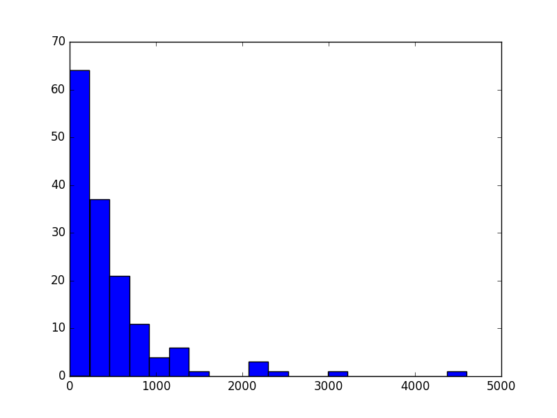

Middle 90% weight data

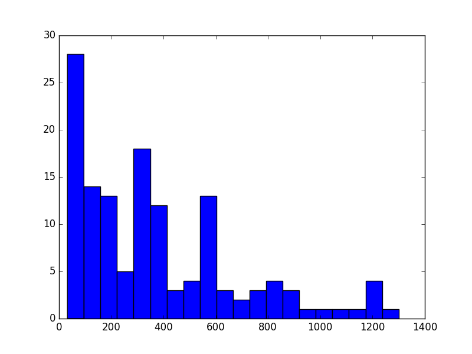